# java-programming-one

Nischal Shakya

2/3/2020

## Data analysis of Java Programming One

Let’s know what kind of data we are dealing with before hand so that we can get insight of variables used in dataset.

```r
str(df)
```

```
## 'data.frame':    35 obs. of  19 variables:
##  $ Roll.No.                               : int  1001749291 1001749046 1001749153 1001749154 1001749155 1001749156 1001749157 1001749158 1001749159 1001749071 ...
##  $ Name                                   : chr  "Aakash Maharjan" "Aakrista Palikhe" "Aashish Thapa Magar" "Amar Agrawal" ...
##  $ Gender                                 : chr  "M" "M" "M" "M" ...
##  $ Assignment.Full.Marks                  : int  30 30 30 30 30 30 30 30 30 30 ...
##  $ Assignment.Marks.Obtained              : int  20 26 21 29 27 23 24 21 22 16 ...
##  $ Mid.Term.Full.Marks                    : int  40 40 40 40 40 40 40 40 40 40 ...
##  $ Mid.Term.Marks.Obtained                : chr  "29" "35" "24" "38" ...
##  $ Mid.Term.Fifteen.Percent.Marks.Obtained: int  11 13 9 14 14 0 11 8 8 8 ...
##  $ Lab.Test.Full.Marks                    : int  20 20 20 20 20 20 20 20 20 20 ...
##  $ Lab.Test.Marks.Obtained                : int  12 3 10 20 18 9 14 3 7 5 ...
##  $ Lab.Test.Fifteen.Percent.Marks.Obtained: int  9 2 8 15 14 7 11 2 5 4 ...
##  $ Internal.Marks                         : int  40 41 38 58 55 30 45 32 36 27 ...
##  $ Final.Exam.Full.Marks                  : int  100 100 100 100 100 100 100 100 100 100 ...
##  $ Final.Exam.Marks.Obtained              : int  58 57 58 82 66 29 48 48 41 57 ...
##  $ Final.Exam.Forty.Percent.Marks         : int  23 23 23 33 26 12 19 19 16 23 ...
##  $ Total                                  : int  63 64 61 91 81 42 64 51 52 50 ...
##  $ Grade                                  : chr  "B-" "B" "B-" "A" ...
##  $ Grade.Point                            : num  2.67 3 2.67 4 4 1.67 2.67 2 2 2 ...
##  $ Remarks                                : chr  "" "" "" "" ...
```

## Student on basics of Grade

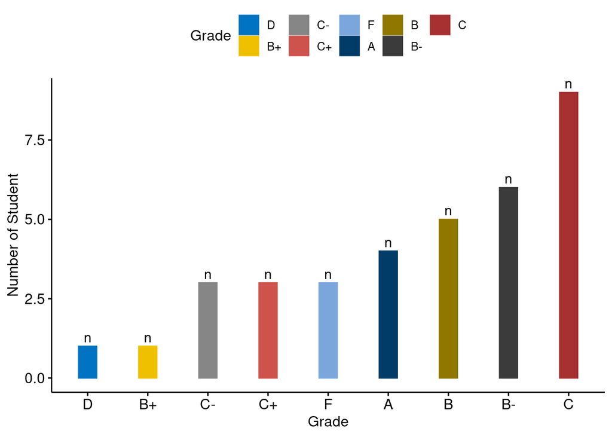

With reference to above bar chart we can see that Grade doesn’t have much more difference between them. So, what we can do is to merge Grade into Excellent, Very Good, Good and Statisfactory. We can divide Grade A falls under Excellent category, B falls under Very Good category, C falls into Good category and D,F falls into statisfactory category. We can acheive that by adding the new column called Range in existing data frame.

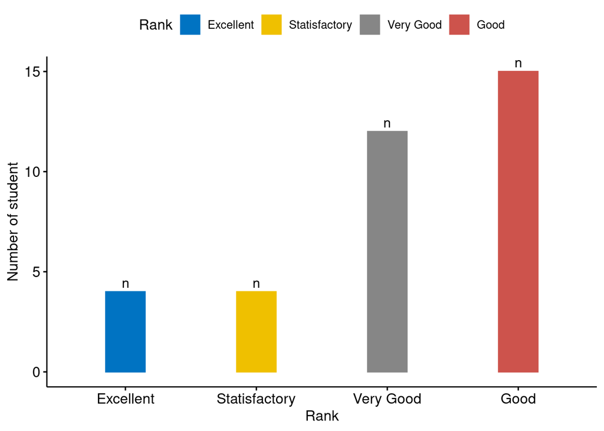

From above barchart, we can see with help of Rank we can generalize data for further analysis.